# Survival Analysis

C. Savonen for ALSF CCDL

2019

**Purpose:**

Set up basic survival analyses models which can be applied to various other data.

#### Usage

To run this from the command line, use:

```
Rscript -e "rmarkdown::render('analyses/survival-analysis/survival-analysis.Rmd',
                              clean = TRUE)"
```

*This assumes you are in the top directory of the repository.*

## Setup

#### Packages and functions

Read in set up script.

```r
if (!("survminer" %in% installed.packages())) {
  install.packages("survminer")
}
library(survminer)

# Magrittr pipe
`%>%` <- dplyr::`%>%`
```

#### Set up files and directories

Set up output directories.

```r
data_dir <- file.path("..", "..", "data")
results_dir <- "results"
plots_dir <- "plots"
```

Make output directories.

```r
if (!dir.exists(results_dir)) {
  dir.create(results_dir)
}
if (!dir.exists(plots_dir)) {
  dir.create(plots_dir)
}
```

Declare input file paths.

```r
metadata_file <- file.path(data_dir, "pbta-histologies.tsv")
tmb_file <- file.path(data_dir, "pbta-snv-consensus-mutation-tmb.tsv")
```

Declare output file paths.

```r
kap_meier_plot_file <- file.path(plots_dir, "survival_curve_gender.pdf")
logrank_table_file <- file.path(results_dir, "logrank_gender.tsv")
cox_table_file <- file.path(results_dir, "cox_regression_tmb.tsv")
```

## Import the metadata

```r
metadata <- readr::read_tsv(metadata_file)
```

```r
metadata$OS_status <- factor(metadata$OS_status, levels = c("LIVING", "DECEASED"))
metadata$OS_status_num <- as.numeric(metadata$OS_status)
```

## Usage

This is the template model that you can follow for all survival analyses here. What will change is the independent variables `<INDEPENDENT_VARIABLES>` you use to try to predict survival. Depending on what type of variable you are using for your independent variables, this will influence what statistical model is appropriate `<STAT_MODEL_FUNCTION>`.

```
<STAT_MODEL_FUNCTION>(survival::Surv(OS_days, OS_status_num) ~ <INDEPENDENT_VARIABLES>,
                 data = metadata)
```

## Kaplan-Meier

The [Kaplan-Meier](https://www.ncbi.nlm.nih.gov/pmc/articles/PMC3059453/) survival curve shows the probability of survival over time.

```r
# Make the model
kap_fit <- survival::survfit(
  survival::Surv(metadata$OS_days, metadata$OS_status_num) ~ reported_gender,
  data = metadata
)

# Print out a cleaned version of this data to look at it
broom::tidy(kap_fit)
```

| time | n.risk | n.event | n.censor | estimate | std.error | conf.high | conf.low | strata |
| --- | --- | --- | --- | --- | --- | --- | --- | --- |
| 1 | 1026 | 2 | 0 | 0.9980507 | 0.001379721 | 1.0000000 | 0.99535540 | reported_gender=Female |
| 4 | 1024 | 0 | 3 | 0.9980507 | 0.001379721 | 1.0000000 | 0.99535540 | reported_gender=Female |
| 10 | 1021 | 2 | 0 | 0.9960956 | 0.001956009 | 0.9999217 | 0.99228421 | reported_gender=Female |
| 15 | 1019 | 0 | 3 | 0.9960956 | 0.001956009 | 0.9999217 | 0.99228421 | reported_gender=Female |
| 23 | 1016 | 0 | 3 | 0.9960956 | 0.001956009 | 0.9999217 | 0.99228421 | reported_gender=Female |
| 31 | 1013 | 3 | 0 | 0.9931457 | 0.002599644 | 0.9982189 | 0.98809828 | reported_gender=Female |
| 33 | 1010 | 0 | 3 | 0.9931457 | 0.002599644 | 0.9982189 | 0.98809828 | reported_gender=Female |
| 39 | 1007 | 5 | 0 | 0.9882145 | 0.003422496 | 0.9948657 | 0.98160776 | reported_gender=Female |
| 42 | 1002 | 0 | 3 | 0.9882145 | 0.003422496 | 0.9948657 | 0.98160776 | reported_gender=Female |
| 50 | 999 | 0 | 3 | 0.9882145 | 0.003422496 | 0.9948657 | 0.98160776 | reported_gender=Female |

[output cut: 675 more lines]

`survminer` package comes with a convenient plotting function which uses `ggplot2` arguments.

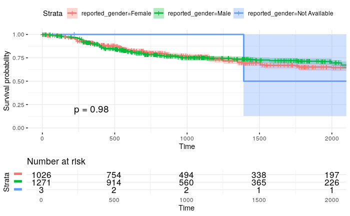

```r
surv_plot <- survminer::ggsurvplot(kap_fit,
  pval = TRUE,
  data = metadata, risk.table = TRUE,
  conf.int = TRUE,
  xlim = c(0, 2000),
  break.time.by = 500,
  ggtheme = theme_minimal(),
  risk.table.y.text.col = T,
  risk.table.y.text = FALSE
)

# Make this plot a combined plot
cowplot::plot_grid(surv_plot[[1]], surv_plot[[2]], nrow = 2, rel_heights = c(2.5, 1))
```

Save the plot to a file.

```r
# We can save the plot like a normal ggplot
ggplot2::ggsave(kap_meier_plot_file)
```

## Log-Rank

For testing whether two survival curves are different, we can use Log-Rank which can be implemented using `survival::survdiff` function. In this example, we will test for survival curve differences between for `reported_gender` categories.

```r
# First let's filter out data that does not have reported_gender available
metadata_filt <- metadata %>%
  dplyr::filter(reported_gender != "Not Available")
```

Use the `survdiff` function to test the differences between the `Male` and `Female` curves.

```r
logrank_fit <- survival::survdiff(
  survival::Surv(metadata_filt$OS_days, metadata_filt$OS_status_num) ~ reported_gender,
  data = metadata_filt
)
```

Make a pretty table of the results.

```r
# Obtain p value for Chi-Squared stat
p.value = pchisq(logrank_fit$chisq, df = 1, lower = FALSE)

# Use broom to make the model object cleaned up
logrank_table <- broom::tidy(logrank_fit) %>%
  dplyr::mutate(p.value)

# Print out the table here
logrank_table %>%
  knitr::kable(digits = 2)
```

| reported_gender | N | obs | exp | p.value |
| --- | --- | --- | --- | --- |
| Female | 1026 | 284 | 284.81 | 0.95 |
| Male | 1271 | 342 | 341.19 | 0.95 |

Save the table data in a TSV.

```r
readr::write_tsv(logrank_table, logrank_table_file)
```

## Cox Regression

Cox Regression is a model suited for survival analysis where your independent variables are continuous. For this example, we’ll use Tumor Mutation Burden as our continuous variable.

```r
# Read in the data
tmb <- readr::read_tsv(tmb_file)
```

```r
tmb_combine <- metadata %>%
  dplyr::inner_join(tmb, by = c("Kids_First_Biospecimen_ID" = "Tumor_Sample_Barcode"))
```

Plug this into a Cox Regression model using the function `survival::coxph`.

```r
cox_fit <- survival::coxph(
  survival::Surv(tmb_combine$OS_days, tmb_combine$OS_status_num) ~ tmb,
  data = tmb_combine
)
```

Take the output from this and make a table.

```r
# Tidy up the model object with broom
cox_table <- broom::tidy(cox_fit)

# Print out the table here
cox_table %>%
  knitr::kable(digits = 3)
```

| term | estimate | std.error | statistic | p.value | conf.low | conf.high |
| --- | --- | --- | --- | --- | --- | --- |
| tmb | 0.051 | 0.013 | 4.024 | 0 | 0.026 | 0.075 |

Save the table data in a TSV.

```r
readr::write_tsv(cox_table, cox_table_file)
```